# Animal rescue incidents attended by London Fire Brigade, 2009-2021

Laurence Horton

28/06/2021

## Animal rescue incidents attended London Fire Brigade by London borough, 2009-2021

I wondered what London borough had the greatest number of incidents over the period covered by the data set.

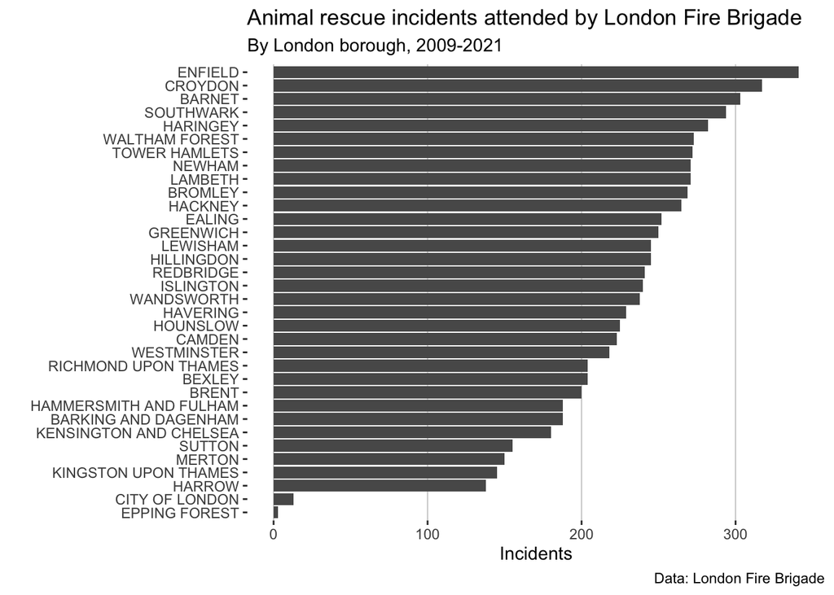

## Animal rescue incidents attended London Fire Brigade by region, 2009-2021

London has an inner and outer region, so what’s the pattern of incidents for those regions?

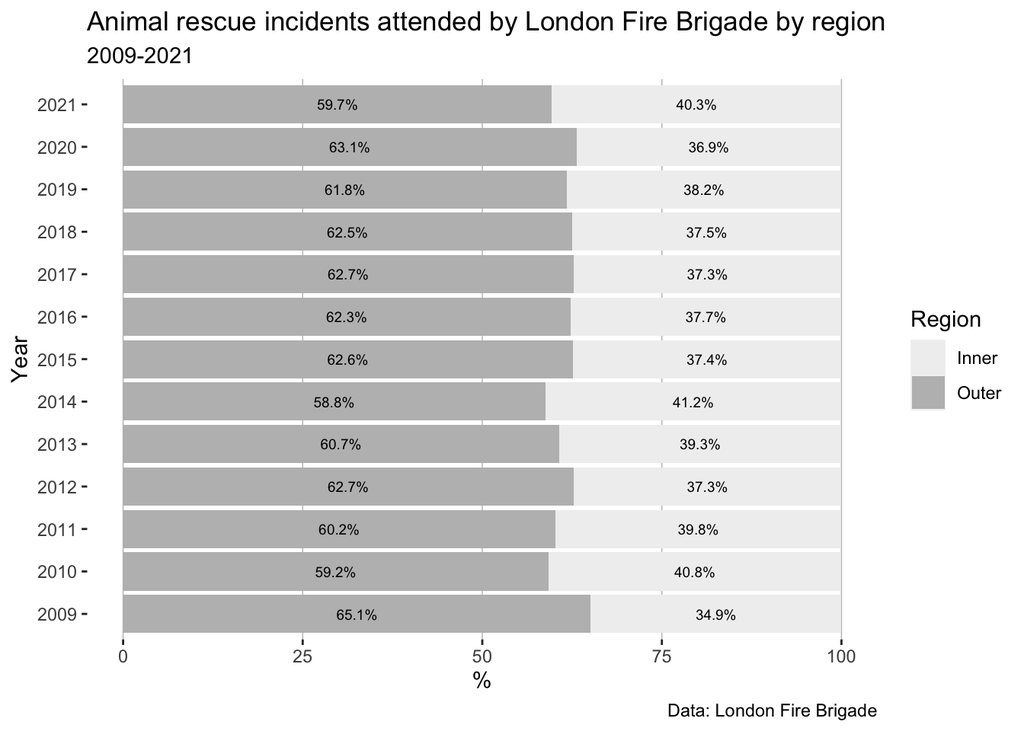

## Map of animal rescue incidents attended London Fire Brigade in Canning Town, 2009-2021

I used to live in Canning Town so I wondered what kind of animal rescue incidents had occurred there.

[interactive chart not shown]

# Citations

## Data

London Fire Brigade (2021) Animal Rescue incidents attended by LFB from Jan 2009. *London Datastore* https://data.london.gov.uk/dataset/animal-rescue-incidents-attended-by-lfb available under an UK Government Open Licence (OGL v3) http://www.nationalarchives.gov.uk/doc/open-government-licence/version/3/

## Code

Horton, L. (2021). #TidyTuesday 2021-06-29 LFB Animal Rescues. GitHub repository, https://github.com/laurencehorton/tidytuesday published under Creative Commons Zero v1.0 Universal https://github.com/laurencehorton/torontobikeshare/blob/master/LICENSE

## Packages

Mock, T. (2021). *Tidy Tuesday: A weekly data project aimed at the R ecosystem*. https://github.com/rfordatascience/tidytuesday.

Cheng, J., Karambelkar, B., Xie, Y. (2019). *leaflet: Create Interactive Web Maps with the JavaScript ‘Leaflet’ Library*. R package version 2.0.3. https://CRAN.R-project.org/package=leaflet

Cheng, J., Sievert, C., Chang, W., Xie, Y., Allen, J. (2021). *htmltools: Tools for HTML*. R package version 0.5.1.1. https://CRAN.R-project.org/package=htmltools

Mock, T. (2021). *Tidy Tuesday: A weekly data project aimed at the R ecosystem*. https://github.com/rfordatascience/tidytuesday.

R Core Team (2018). *R: A language and environment for statistical computing. R Foundation for Statistical Computing*, Vienna, Austria. URL https://www.R-project.org/.

Wickham, H., François, R., Henry, L., Müller K. (2021). *dplyr: A Grammar of Data Manipulation. R package version 1.0.6*. https://CRAN.R-project.org/package=dplyr